# Data Processing, Summarization, and Visualization

Brian Higginbotham

# Project Overview

This project is focused on data processing with the end goal of producing meaningful summaries and graphics. We will use data files from the U.S. Census Bureau on school enrollment populations and general overall populations. One of the main objectives is to create generalized functions that can process and transform data for easy summation and graphic presentation. Our focus on the Census information will be to graph enrollment and population data.

## Data

The data files used in this project are from the Census Bureau. `EDU` files contain school enrollment data and `PST` files contain population data:

- https://www4.stat.ncsu.edu/~online/datasets/EDU01a.csv
- https://www4.stat.ncsu.edu/~online/datasets/EDU01b.csv
- https://www4.stat.ncsu.edu/~online/datasets/PST01a.csv
- https://www4.stat.ncsu.edu/~online/datasets/PST01b.csv
- https://www4.stat.ncsu.edu/~online/datasets/PST01c.csv
- https://www4.stat.ncsu.edu/~online/datasets/PST01d.csv

The following packages were used:

```r
library(tidyverse)
library(readr)
```

## Data Processing

### First Steps

First, let’s read in a single data sheet. We’ll start with the `EDU` data, so our data points of interest are going to be enrollment (EDU01a)

```r
library(readr)
sheet1 <- read_csv("https://www4.stat.ncsu.edu/~online/datasets/EDU01a.csv")
head(sheet1)
```

| Area_name | STCOU | EDU010187F | EDU010187D | EDU010187N1 | EDU010187N2 | EDU010188F | EDU010188D | EDU010188N1 | EDU010188N2 | EDU010189F | EDU010189D | EDU010189N1 | EDU010189N2 | EDU010190F | EDU010190D | EDU010190N1 | EDU010190N2 | EDU010191F | EDU010191D | EDU010191N1 | EDU010191N2 | EDU010192F | EDU010192D | EDU010192N1 | EDU010192N2 | EDU010193F | EDU010193D | EDU010193N1 | EDU010193N2 | … |
| --- | --- | --- | --- | --- | --- | --- | --- | --- | --- | --- | --- | --- | --- | --- | --- | --- | --- | --- | --- | --- | --- | --- | --- | --- | --- | --- | --- | --- | --- | --- |
| UNITED STATES | 00000 | 0 | 40024299 | 0000 | 0000 | 0 | 39967624 | 0000 | 0000 | 0 | 40317775 | 0000 | 0000 | 0 | 40737600 | 0000 | 0000 | 0 | 41385442 | 0000 | 0000 | 0 | 42088151 | 0000 | 0000 | 0 | 42724710 | 0000 | 0000 | … |
| ALABAMA | 01000 | 0 | 733735 | 0000 | 0000 | 0 | 728234 | 0000 | 0000 | 0 | 730048 | 0000 | 0000 | 0 | 728252 | 0000 | 0000 | 0 | 725541 | 0000 | 0000 | 0 | 726150 | 0000 | 0000 | 0 | 728014 | 0000 | 0000 | … |
| Autauga, AL | 01001 | 0 | 6829 | 0000 | 0000 | 0 | 6900 | 0000 | 0000 | 0 | 6920 | 0000 | 0000 | 0 | 6847 | 0000 | 0000 | 0 | 7008 | 0000 | 0000 | 0 | 7137 | 0000 | 0000 | 0 | 7152 | 0000 | 0000 | … |
| Baldwin, AL | 01003 | 0 | 16417 | 0000 | 0000 | 0 | 16465 | 0000 | 0000 | 0 | 16799 | 0000 | 0000 | 0 | 17054 | 0000 | 0000 | 0 | 17479 | 0000 | 0000 | 0 | 17983 | 0000 | 0000 | 0 | 18735 | 0000 | 0000 | … |
| Barbour, AL | 01005 | 0 | 5071 | 0000 | 0000 | 0 | 5098 | 0000 | 0000 | 0 | 5068 | 0000 | 0000 | 0 | 5156 | 0000 | 0000 | 0 | 5173 | 0000 | 0000 | 0 | 5252 | 0000 | 0000 | 0 | 5135 | 0000 | 0000 | … |
| Bibb, AL | 01007 | 0 | 3557 | 0000 | 0000 | 0 | 3508 | 0000 | 0000 | 0 | 3571 | 0000 | 0000 | 0 | 3621 | 0000 | 0000 | 0 | 3652 | 0000 | 0000 | 0 | 3564 | 0000 | 0000 | 0 | 3565 | 0000 | 0000 | … |

Inspecting the head of the data file, we see that there are 42 columns. Our points of interest, enrollment, are all the columns that end in “D”. So now we will reduce the size of our data file by selecting only the columns that correspond to enrollment as well as `Area_name` and `STCOU`. These last two columns will be needed to create the visualizations.

```r
sheet1 <- sheet1 %>%
  select(Area_name, STCOU, ends_with("D")) %>%
  rename("area_name" = Area_name)
# Run attributes() to check column selection
attributes(sheet1)$names
```

```
##  [1] "area_name"  "STCOU"      "EDU010187D" "EDU010188D" "EDU010189D"
##  [6] "EDU010190D" "EDU010191D" "EDU010192D" "EDU010193D" "EDU010194D"
## [11] "EDU010195D" "EDU010196D"
```

A quick glance at a data file shows that our main point of interest, enrollment or population, is in a wide format - that is the population data is spread about between multiple columns. In order to run any kind of analysis on the enrollment numbers we’ll need to convert the enrollment data to long format - that is, move all the enrollment data into one column.

```r
sheet1 <- sheet1 %>%
  pivot_longer(cols=3:12, names_to="edu_code", values_to = "enrollment")
# run str() to check pivot
str(sheet1)
```

```
## tibble [31,980 × 4] (S3: tbl_df/tbl/data.frame)
##  $ area_name : chr [1:31980] "UNITED STATES" "UNITED STATES" "UNITED STATES" "UNITED STATES" ...
##  $ STCOU     : chr [1:31980] "00000" "00000" "00000" "00000" ...
##  $ edu_code  : chr [1:31980] "EDU010187D" "EDU010188D" "EDU010189D" "EDU010190D" ...
##  $ enrollment: num [1:31980] 40024299 39967624 40317775 40737600 41385442 ...
```

Parse the new column “edu_code” to pull out the year and convert to YYYY format Grab the first 7 characters of the new column “edu_code”

```r
# In the first step we drop the "D" from the "edu" column and then split the resulting column into two new columns - "edu_code" overwritten to now contain the first three characters and four digits of the old "edu_code" column, and "yr" which contains the last two digits of the year for the enrollment value
sheet1 <- sheet1 %>%
  mutate(edu_code=substr(sheet1$edu_code, 1, 9)) %>%
  separate(edu_code, into=c("edu_code", "yr"), sep=7, remove = TRUE, convert = FALSE)
# In the second step, we evaluate if the new column "yr" is greater than 50. If so, we paste0 "19" to it's value and force the value to be read as numeric; if the column value is less than 50, we paste "20" to the value and force the value to be read as numeric.
sheet1 <- sheet1 %>%
  mutate(yr = if_else(sheet1$yr > 50, as.numeric(paste0("19", sheet1$yr, sep="")), as.numeric(paste0("20", sheet1$yr, sep=""))))
# print random rows to check code parsing
sheet1[4433:4438, ]
```

| area_name | STCOU | edu_code | yr | enrollment |
| --- | --- | --- | --- | --- |
| Dodge, GA | 13091 | EDU0101 | 1989 | 3381 |
| Dodge, GA | 13091 | EDU0101 | 1990 | 3282 |
| Dodge, GA | 13091 | EDU0101 | 1991 | 3272 |
| Dodge, GA | 13091 | EDU0101 | 1992 | 3289 |
| Dodge, GA | 13091 | EDU0101 | 1993 | 3316 |
| Dodge, GA | 13091 | EDU0101 | 1994 | 3323 |

Now we split the data file into two separate data files:

- `county` containing only the county-level rows
- `state` containing the non-county level rows

Add appropriate `class` to each

```r
county_df <- sheet1[grep(pattern = ", \\w\\w", sheet1$area_name), ]
class(county_df) <- c("county", class(county_df))
state_df <- sheet1[-c(grep(pattern = ", \\w\\w", sheet1$area_name)), ]
class(state_df) <- c("state", class(state_df))
# print random rows to check output
county_df[1:4, ]
```

| area_name | STCOU | edu_code | yr | enrollment |
| --- | --- | --- | --- | --- |
| Autauga, AL | 01001 | EDU0101 | 1987 | 6829 |
| Autauga, AL | 01001 | EDU0101 | 1988 | 6900 |
| Autauga, AL | 01001 | EDU0101 | 1989 | 6920 |
| Autauga, AL | 01001 | EDU0101 | 1990 | 6847 |

```r
# print random rows to check output
state_df[60:64, ]
```

| area_name | STCOU | edu_code | yr | enrollment |
| --- | --- | --- | --- | --- |
| CALIFORNIA | 06000 | EDU0101 | 1996 | 5468287 |
| COLORADO | 08000 | EDU0101 | 1987 | 555678 |
| COLORADO | 08000 | EDU0101 | 1988 | 560236 |
| COLORADO | 08000 | EDU0101 | 1989 | 560081 |
| COLORADO | 08000 | EDU0101 | 1990 | 562755 |

Add column containing state information for the county-level tibble

```r
county_df <- county_df %>%
  mutate("state" = substr(county_df$area_name, nchar(county_df$area_name)-1, nchar(county_df$area_name)))
# select a few random counties on a single year to check that "state" column matches county
filter(county_df, yr == 1990 & STCOU %in% c("40001", "10001", "20001", "30001", "25001"))
```

| area_name | STCOU | edu_code | yr | enrollment | state |
| --- | --- | --- | --- | --- | --- |
| Kent, DE | 10001 | EDU0101 | 1990 | 22201 | DE |
| Allen, KS | 20001 | EDU0101 | 1990 | 2863 | KS |
| Barnstable, MA | 25001 | EDU0101 | 1990 | 26578 | MA |
| Beaverhead, MT | 30001 | EDU0101 | 1990 | 1704 | MT |
| Adair, OK | 40001 | EDU0101 | 1990 | 4510 | OK |

Add column to non-county tibble corresponding to the state’s classification of division

```r
# created a vector for each regional division containing the names of the states within the division
new_england <- c("CONNECTICUT", "MAINE", "MASSACHUSETTS", "NEW HAMPSHIRE", "RHODE ISLAND", "VERMONT")
mid_atlantic <- c("NEW JERSEY", "NEW YORK", "PENNSYLVANIA")
east_north_central <- c("ILLINOIS", "INDIANA", "MICHIGAN", "OHIO", "WISCONSIN")
west_north_central <- c("IOWA", "KANSAS", "MINNESOTA", "MISSOURI", "NEBRASKA", "NORTH DAKOTA", "SOUTH DAKOTA")
# included District of Columbia in the South Atlantic Division since both Maryland and Virginia are in this division
south_atlantic <- c("DELAWARE", "FLORIDA", "GEORGIA", "MARYLAND", "NORTH CAROLINA", "SOUTH CAROLINA", "VIRGINIA", "DISTRICT OF COLUMBIA", "WEST VIRGINIA", "DISTRICT OF COLUMBIA")
east_south_central <- c("ALABAMA", "KENTUCKY", "MISSISSIPPI", "TENNESSEE")
west_south_central <- c("ARKANSAS", "LOUISIANA", "OKLAHOMA", "TEXAS")
mountain <- c("ARIZONA", "COLORADO", "IDAHO", "MONTANA", "NEVADA", "NEW MEXICO", "UTAH", "WYOMING")
pacific <- c("ALASKA", "CALIFORNIA", "HAWAII", "OREGON", "WASHINGTON")
# created division column using if/else logic
state_df <- state_df %>%
  mutate("division" = if_else(area_name %in% new_england, "New England",
          if_else(area_name %in% mid_atlantic, "Mid Atlantic",
          if_else(area_name %in% east_north_central, "East North Central",
          if_else(area_name %in% west_north_central, "West North Central",
          if_else(area_name %in% south_atlantic, "South Atlantic",
          if_else(area_name %in% east_south_central, "East South Central",
          if_else(area_name %in% west_south_central, "West South Central",
          if_else(area_name %in% mountain, "Mountain",
          if_else(area_name %in% pacific, "Pacific", "ERROR"))))))))))
# select a few random states filtered on a single year to prevent duplication to check that division matches state
filter(state_df, yr == 1990 & area_name %in% c("ARIZONA", "CALIFORNIA", "OHIO", "MARYLAND", "MAINE"))
```

| area_name | STCOU | edu_code | yr | enrollment | division |
| --- | --- | --- | --- | --- | --- |
| ARIZONA | 04000 | EDU0101 | 1990 | 617753 | Mountain |
| CALIFORNIA | 06000 | EDU0101 | 1990 | 4771978 | Pacific |
| MAINE | 23000 | EDU0101 | 1990 | 208703 | New England |
| MARYLAND | 24000 | EDU0101 | 1990 | 698806 | South Atlantic |
| OHIO | 39000 | EDU0101 | 1990 | 1796495 | East North Central |

### Write Functions

Now that we’ve processed the data into a form that we can use for summaries, we’ll now want to combine all the transformations into a few functions that will be able to call in the data and process it to the desired structure.

Read in second data sheet (EDU01b)

```r
sheet2 <- read_csv("https://www4.stat.ncsu.edu/~online/datasets/EDU01b.csv")
```

Write a function to select/rename columns and pivot to long format

```r
# included option argument to name column with enrollment data
select_and_pivot <- function(sheet, var_name = "population") {
  df <- sheet %>%
            select(Area_name, STCOU, ends_with("D")) %>%
            rename("area_name" = Area_name) %>%
            pivot_longer(cols=3:12, names_to="census_code", values_to = var_name)
  return(df)
}
census <- select_and_pivot(sheet2, var_name = "enroll")
# run str() to check structure of pivoted data
str(census)
```

```
## tibble [31,980 × 4] (S3: tbl_df/tbl/data.frame)
##  $ area_name  : chr [1:31980] "UNITED STATES" "UNITED STATES" "UNITED STATES" "UNITED STATES" ...
##  $ STCOU      : chr [1:31980] "00000" "00000" "00000" "00000" ...
##  $ census_code: chr [1:31980] "EDU010197D" "EDU010198D" "EDU010199D" "EDU010200D" ...
##  $ enroll     : num [1:31980] 44534459 46245814 46368903 46818690 47127066 ...
```

Write a function that takes the output from `select_and_pivot()` and creates a *year* column and a census description column (*edu_code*)

```r
create_code_yr <- function(sheet) {
  dfa <- sheet %>%
           mutate(census_code=substr(sheet$census_code, 1, 9)) %>%
           separate(census_code, into=c("census_code", "yr"), sep=7, remove = TRUE, convert = FALSE)
  dfb <- dfa %>%
           mutate(yr = if_else(dfa$yr > 50, as.numeric(paste0("19", dfa$yr, sep="")), as.numeric(paste0("20", dfa$yr, sep=""))))
  return(dfb)
}
census <- create_code_yr(census)
# check str() to see structure of augmented tibble
str(census)
```

```
## tibble [31,980 × 5] (S3: tbl_df/tbl/data.frame)
##  $ area_name  : chr [1:31980] "UNITED STATES" "UNITED STATES" "UNITED STATES" "UNITED STATES" ...
##  $ STCOU      : chr [1:31980] "00000" "00000" "00000" "00000" ...
##  $ census_code: chr [1:31980] "EDU0101" "EDU0101" "EDU0101" "EDU0102" ...
##  $ yr         : num [1:31980] 1997 1998 1999 2000 2001 ...
##  $ enroll     : num [1:31980] 44534459 46245814 46368903 46818690 47127066 ...
```

Write a function that will add a state information column (*state*) to the county-level tibble

```r
create_state <- function(sheet) {
  df <- sheet %>%
    mutate("state" = substr(sheet$area_name, nchar(sheet$area_name)-1, nchar(sheet$area_name)))
  return(df)
}
```

Write a function that will add a division classification column (*division*) to the non-county tibble

```r
create_division <- function(sheet) {
  df <- sheet %>%
    mutate("division" = if_else(area_name %in% new_england, "New England",
            if_else(area_name %in% mid_atlantic, "Mid Atlantic",
            if_else(area_name %in% east_north_central, "East North Central",
            if_else(area_name %in% west_north_central, "West North Central",
            if_else(area_name %in% south_atlantic, "South Atlantic",
            if_else(area_name %in% east_south_central, "East South Central",
            if_else(area_name %in% west_south_central, "West South Central",
            if_else(area_name %in% mountain, "Mountain",
            if_else(area_name %in% pacific, "Pacific", "ERROR"))))))))))
  return(df)
}
```

Write a function that takes the output from `create_code_yr()` and creates two tibbes - one for county rows and another for non-county rows. Add *state* column to county tibble and add *division classification* to non-county tibble. **Return one object with two tibbles**

```r
split_county_state <- function(sheet) {
  county <- sheet[grep(pattern = ", \\w\\w", sheet$area_name), ]
  class(county) <- c("county", class(county))
  county <- create_state(county)
  state <- sheet[-c(grep(pattern = ", \\w\\w", sheet$area_name)), ]
  state <- state %>%
    filter(area_name != "District of Columbia")
  class(state) <- c("state", class(state))
  state <- create_division(state)
# return a list with two tibbles. Labeled each item in the list to access each tibble later with $ query syntax
  return(list(county = county, state = state))
}
census <- split_county_state(census)
# print random rows filtered by year to check county and state tibbles
# filtered by year to reduce the redundancy of area_name
# for spot-checking purposes only
filter(census$county, yr == 1999 & STCOU %in% c("13001", "24001", "33001", "39001", "42001"))
```

| area_name | STCOU | census_code | yr | enroll | state |
| --- | --- | --- | --- | --- | --- |
| Appling, GA | 13001 | EDU0101 | 1999 | 3474 | GA |
| Allegany, MD | 24001 | EDU0101 | 1999 | 10978 | MD |
| Belknap, NH | 33001 | EDU0101 | 1999 | 9324 | NH |
| Adams, OH | 39001 | EDU0101 | 1999 | 5461 | OH |
| Adams, PA | 42001 | EDU0101 | 1999 | 14552 | PA |

```r
filter(census$state[225:275, ], yr == 2002)
```

| area_name | STCOU | census_code | yr | enroll | division |
| --- | --- | --- | --- | --- | --- |
| MASSACHUSETTS | 25000 | EDU0102 | 2002 | 973467 | New England |
| MICHIGAN | 26000 | EDU0102 | 2002 | 1730668 | East North Central |
| MINNESOTA | 27000 | EDU0102 | 2002 | 854122 | West North Central |
| MISSISSIPPI | 28000 | EDU0102 | 2002 | 493507 | East South Central |
| MISSOURI | 29000 | EDU0102 | 2002 | 915129 | West North Central |

Lastly, we’ll create a `wrapper function` that will take in a URL address to one CSV file and return two tibbles in a single object

```r
process_data <- function(url, var_name = "population") {
  a <- read_csv(url)
  b <- select_and_pivot(a, var_name)
  c <- create_code_yr(b)
  d <- split_county_state(c)
  return(d)
}
```

### Call It & Combine

Call the wrapper function twice, once for each census file (EDU01a & EDU01b)

```r
edu_01a <- process_data("https://www4.stat.ncsu.edu/~online/datasets/EDU01a.csv", var_name = "pop")

edu_01b <- process_data("https://www4.stat.ncsu.edu/~online/datasets/EDU01b.csv", var_name = "pop")
```

Write a function to combine the county and non-county tibbles of the above outputs

```r
combine_data <- function(data_1, data_2) {
  a <- bind_rows(data_1$county, data_2$county)
  b <- bind_rows(data_1$state, data_2$state)
# Labeled each item in the list to access each tibble later with $ query syntax
  return(list(county = a,state = b))
}
```

Call combine function

```r
edu_01 <- combine_data(edu_01a, edu_01b)
# print random rows filtered by year to check county and state tibbles
# filtered by year to reduce the redundancy of area_name
# used one year each csv file to ensure data combined
# for spot-checking purposes only
filter(edu_01$county, ((yr == 2001) | (yr == 1991)) & STCOU %in% c("08013", "18011", "22033", "36005", "48009"))
```

| area_name | STCOU | census_code | yr | pop | state |
| --- | --- | --- | --- | --- | --- |
| Boulder, CO | 08013 | EDU0101 | 1991 | 36572 | CO |
| Boone, IN | 18011 | EDU0101 | 1991 | 6995 | IN |
| East Baton Rouge, LA | 22033 | EDU0101 | 1991 | 63350 | LA |
| Bronx, NY | 36005 | EDU0101 | 1991 | 0 | NY |
| Archer, TX | 48009 | EDU0101 | 1991 | 1706 | TX |
| Boulder, CO | 08013 | EDU0102 | 2001 | 47246 | CO |
| Boone, IN | 18011 | EDU0102 | 2001 | 8624 | IN |
| East Baton Rouge, LA | 22033 | EDU0102 | 2001 | 57715 | LA |
| Bronx, NY | 36005 | EDU0102 | 2001 | 0 | NY |
| Archer, TX | 48009 | EDU0102 | 2001 | 2012 | TX |

```r
filter(edu_01$state, (yr == 2001) | (yr == 1991))
```

| area_name | STCOU | census_code | yr | pop | division |
| --- | --- | --- | --- | --- | --- |
| UNITED STATES | 00000 | EDU0101 | 1991 | 41385442 | ERROR |
| ALABAMA | 01000 | EDU0101 | 1991 | 725541 | East South Central |
| ALASKA | 02000 | EDU0101 | 1991 | 112190 | Pacific |
| ARIZONA | 04000 | EDU0101 | 1991 | 634201 | Mountain |
| ARKANSAS | 05000 | EDU0101 | 1991 | 436209 | West South Central |
| CALIFORNIA | 06000 | EDU0101 | 1991 | 4949910 | Pacific |
| COLORADO | 08000 | EDU0101 | 1991 | 574213 | Mountain |
| CONNECTICUT | 09000 | EDU0101 | 1991 | 469013 | New England |
| DELAWARE | 10000 | EDU0101 | 1991 | 99672 | South Atlantic |
| DISTRICT OF COLUMBIA | 11000 | EDU0101 | 1991 | 80694 | South Atlantic |

[output cut: 94 more lines]

## Summarizing

Here, we’ll create the plotting functions for both the state and county data frames. Note that the county data frame includes dynamic arguments that allow the user to select `state`, order (top or bottom), and the total number of counties to be included.

`state` plotting method:

```r
# calculates the mean of the var_name (population) by regional division and year
# filters out all rows were division == "ERROR"
plot.state <- function(df, var_name = "population") {
  new_df <- df %>%
    group_by(division, yr) %>%
    summarise(ENRmean = mean(get(var_name))) %>%
    filter(division != "ERROR")

# plots a line graph of the mean var_name (population) by year for each regional division
  ggplot(new_df, aes(x = yr, y = ENRmean, color = division)) +
    geom_line() + scale_y_continuous(labels = scales::comma) + ylab(var_name)
}
```

`county` plotting method

```r
# order defaults to "top", so if order argument is left blank or if "top" is entered, the function will return dataframe in descending order. If "bottom" is entered for the argument, the dataframe will return in ascending order. If anything other than "top" or "bottom" is entered, the function will STOP and request user to enter appropriate argument
plot.county <- function(df, var_name = "population", st = "IL", order = "top", n = 5) {
  if(order == "top"){
  new_df <- df %>%
    filter(state == st) %>%
    group_by(area_name) %>%
    summarise(ENRmean = mean(get(var_name))) %>%
    arrange(desc(ENRmean))
  }
  else if(order == "bottom"){
    new_df <- df %>%
      filter(state == st) %>%
      group_by(area_name) %>%
      summarise(ENRmean = mean(get(var_name))) %>%
      arrange(ENRmean)
  }
  else{
    stop("Specify Order (top or bottom)")
  }
# the above function returns the highest or lowest means of var_name (population) grouped by county for the state entered in the argument.
# the below function filters the original input dataframe based on the area_names of the above results, so that the new dataframe (filter_df) contains non-aggregated data for the counties identified in the above results
  new_df <- new_df[1:n, ]
  filter_df <- df %>%
    filter(area_name %in% new_df$area_name)

# plots a line graph of the var_name (population) for each year for the top or bottom 'n' counties for the state entered in the function argument
  ggplot(filter_df, aes(x = yr, y = get(var_name), color = area_name)) +
    geom_line() + scale_y_continuous(labels = scales::comma) + ylab(var_name)
}
```

## Put It Together

Here we combine all of the functions, wrapper functions, and plotting functions to read in, process, transform, and plot the education/population data. First, we’ll run the functions on the EDU data. Second, we’ll run the functions on population data.

### EDU URLs

Run the data processing function on the two EDU URLs

```r
edu_01a <- process_data("https://www4.stat.ncsu.edu/~online/datasets/EDU01a.csv", var_name = "pop")
edu_01b <- process_data("https://www4.stat.ncsu.edu/~online/datasets/EDU01b.csv", var_name = "pop")
```

Combine function

```r
edu_01 <- combine_data(edu_01a, edu_01b)
```

Plot `state` dataframe

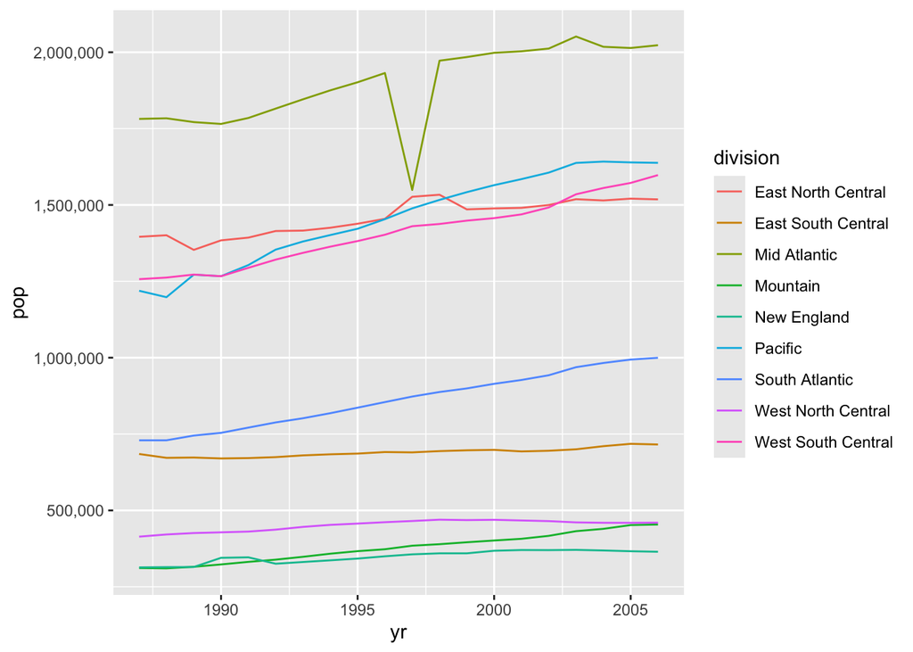

```r
plot(edu_01$state, var_name = "pop")
```

Plot `county` dataframe - North Carolina

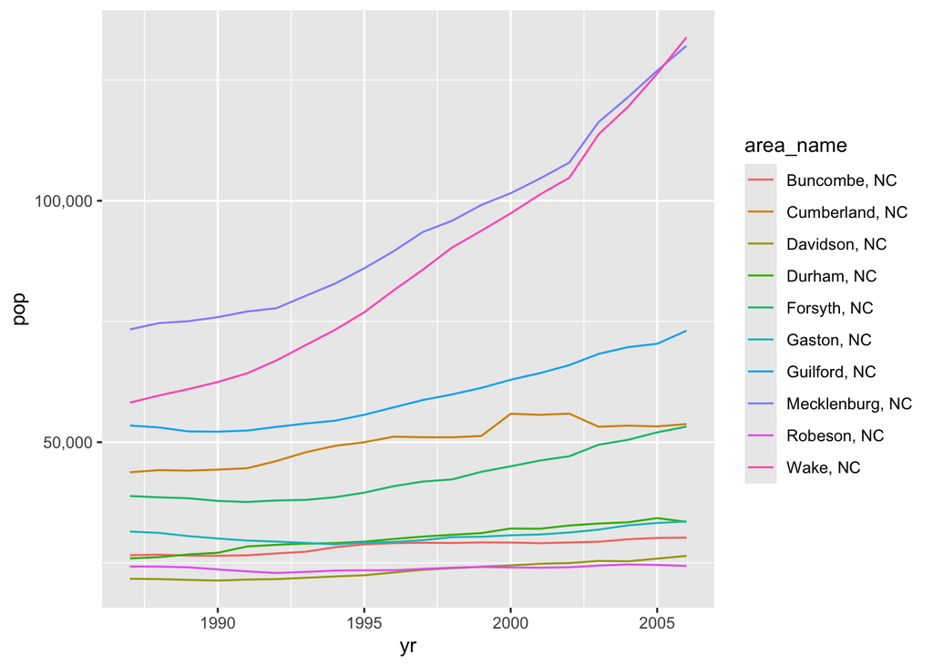

```r
plot(edu_01$county, "pop", "NC", "top", 10)
```

Plot `county` dataframe - Arizona

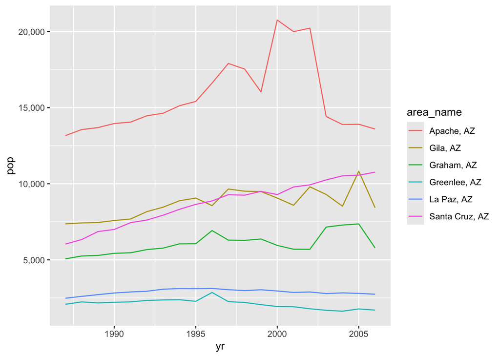

```r
plot(edu_01$county, "pop", "AZ", "bottom", 6)
```

Plot `county` dataframe - defaults

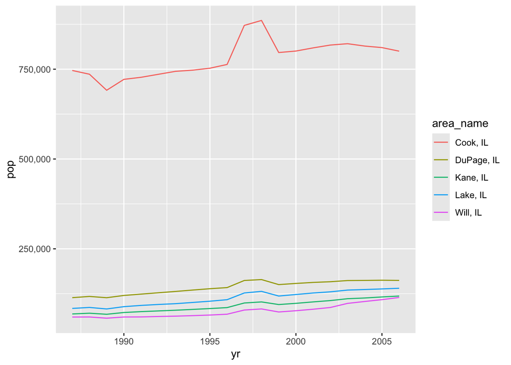

```r
# Have to specify var_name since the plotting default ("population") would not match data source ("pop")
plot(edu_01$county, "pop")
```

Plot `county` dataframe - Ohio

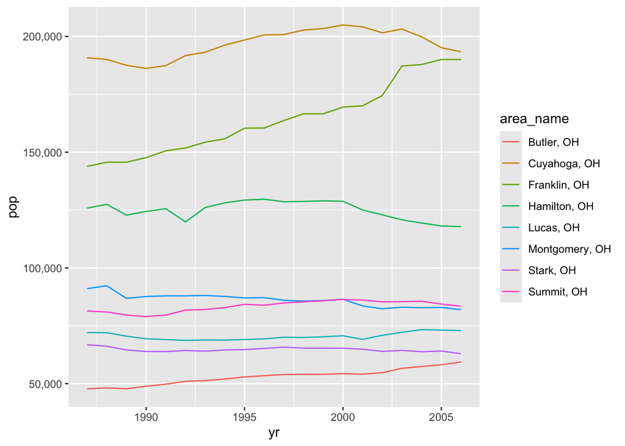

```r
plot(edu_01$county, "pop", "OH", "top", 8)
```

### PST URLs

```r
pst_01a <- process_data("https://www4.stat.ncsu.edu/~online/datasets/PST01a.csv")
pst_01b <- process_data("https://www4.stat.ncsu.edu/~online/datasets/PST01b.csv")
pst_01c <- process_data("https://www4.stat.ncsu.edu/~online/datasets/PST01c.csv")
pst_01d <- process_data("https://www4.stat.ncsu.edu/~online/datasets/PST01a.csv")
```

Combine function

```r
pst_01 <- combine_data(pst_01a, pst_01b)
pst_01 <- combine_data(pst_01c, pst_01)
pst_01 <- combine_data(pst_01d, pst_01)
```

Plot `state` dataframe

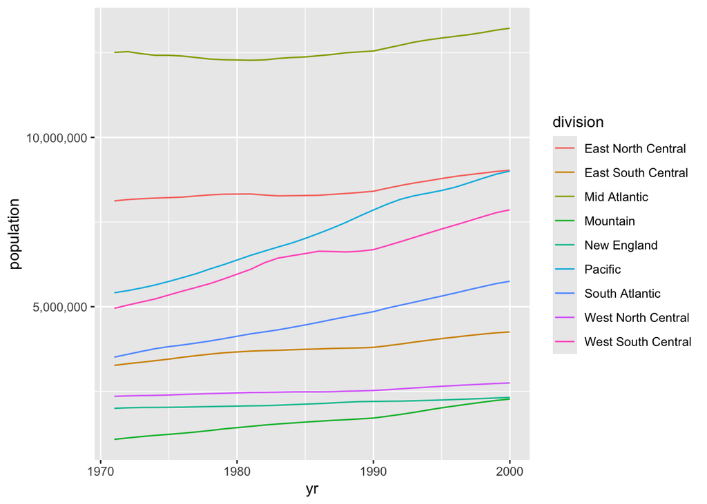

```r
plot(pst_01$state)
```

Plot `county` dataframe - Pennsylvania

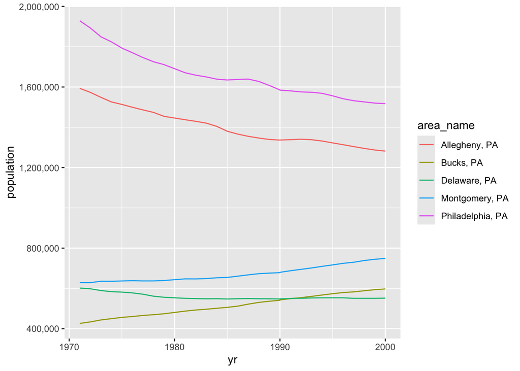

```r
# used ',,' as a place holder for empty arguments
# this allows the function to utilize default values
plot(pst_01$county,,"PA",, 5)
```

Plot `county` dataframe - Texas

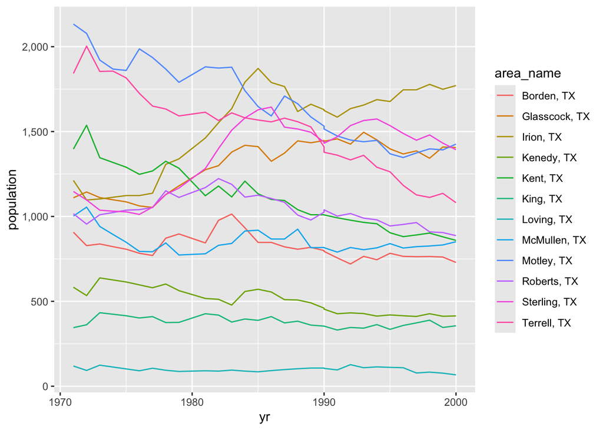

```r
# used ',,' as a place holder for empty arguments
# this allows the function to utilize default values
plot(pst_01$county,,"TX","bottom", 12)
```

Plot `county` dataframe - default

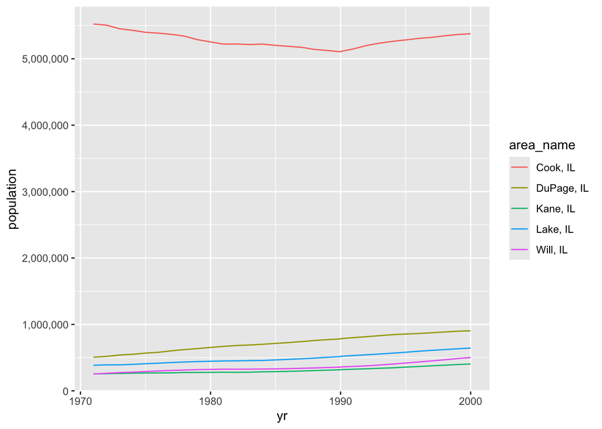

```r
plot(pst_01$county)
```

Plot `county` dataframe - New York

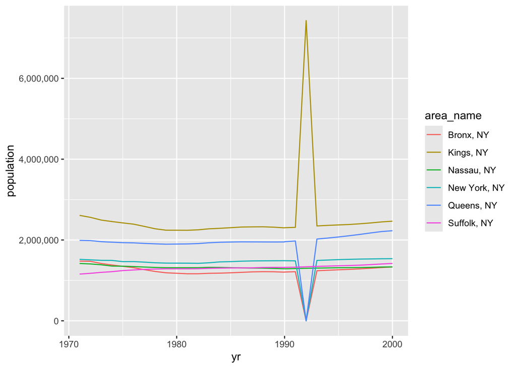

```r
# used ',,' as a place holder for empty arguments
# this allows the function to utilize default values
plot(pst_01$county,,"NY",, 6)
```

The above graph indicates a data error for the year 1992. At first glance, it would appear that the populations of all NYC boroughs were reported in the single borough of Kings, NY.